# Effekten av 1 vs 3 sett

Håvard Crantz Lorentzen

15 11 2021

## 1 vs 3 sett

## Introduksjon

Styrketrening blir mer og mer polulært i det norske samfunn, og tall fra Levekårundersøkelsen i 2019 viser at 4 av 5 trener styrke en gang i uken (Statistisk sentralbyrå 2019). Konseptet styrketrening handler om at man ønsker å styrke kroppen, men hvordan gjør man det på lettests mulig måte? Tradisjonelt gjør man en styrkeøvelse kjør man en øvelse X antall ganger (repetisjoner) og i X antall serier (sett). Men hvor mye har det å si at man ett eller flere sett? Flere studier har sett på effekten av å gjøre ett sett og tre sett (Galvão and Taaffe 2005; Hass et al. 2000; Krieger 2009; Radaelli et al. 2014; Schoenfeld et al. 2019). Resultatet i studiene er sprikende. Noen studier finner ikke forskjell mellom grupper som trener ett og tre sett (Hass et al. 2000 ; Radaelli et al. 2014), mens andre studier ser at begge gruppene øker, men tre sett gir en ytterlige effekt på styrke (Krieger 2009; Galvão and Taaffe 2005). Det er også sett at man kan oppnå like styrkeeffekter, men at økningen av muskelmasse trenger større volum enn 1 sett for å gi effekt (Schoenfeld et al. 2019).

Basert på statestikken fra Statisistik stentralberå (2019) er det mange som får til å trene styrke en gang i uken, men vi vet at skal må få gunstig styrkeeffekt, må man trene 2-3 ganger i uken (Schoenfeld, Ogborn, and Krieger 2016). På bagrunn av dette vil det være gunstig å finne ut av spørsmålet om ett sett er nok, da en treningsøkt tar mye kortere tid. Noe av det som gjør at det er vanskelig å dra en tydelig konklusjon av studiene på området er at det vil være individuelle variajsoner. Derfor er det er det intersant å gjøre studie på hvor en trener ett sett på ene benet og tre sett på andre benet. På denne måten vil en sikre at framgangen ikke blir forskjellig på bagrunn av at gruppeforskjeller.

I denne studien ønsker vi å se videre på effekten av ett og tre sett, hvor vi først ønsker å se på effekten av en kort treningsperiode (5 uker) og en lengre treningsperiode (12 uker). Vi hypotetiserer at begge gruppene vil ha en god framgang i både styrke og muskelstørrelse, men at gruppen som trener tre sett vil få en bedre fremgang ved både 5 og 12 uker.

## Metode

### Etikk

Alle deltagere i studien ble informert om potensielle risikoer ved trening og testing og eventuelle ubehagelige og anstrengende situasjoner og gav et informert samtykke. Alle prosedyrer er i tråd med Helsinkideklarasjonen.

### Deltagere

Det ble rekruttert 41 kvinner og menn til en treningsperiode på 12 uker. Kriterier for å være med var at de måtte være mellom 18-40 år og ikke røyke. De kunne heller ikke være måtte også være vant til å trene (mer enn en økt uka det siste året). I analysene av styrkefremgang ble bare 29 deltagere inkludert de resterende ikke møtte opp på test ved fem uker. 34 deltagere ble analysert for muskelmasseøkning (bare test ved pre og post), resterende gjennomførte ikke studien (fem stk pga. smerter, en stk. pga skade som ikke hadde med studien å gjøre og en pga. ikke fulgte protokoll).

### Trening

Trenging som ble gjennomført var et helkroppstreningsprogram hvor treningen av ble gjort forskjellig på høyre og venstre fot. De ene bene trente ett sett, mens det andre trente tre sett. Hvilket ben som trente hva, ble randomisert. Antall repetisjoner 0-2 uker var 10 repetisjoner maksimum (RM), uke 2-5 var det 8RM, uke 5-12 var det 7RM. Det ble gjort treninger i uken, med unntak av ukene hvor det ble gjort test. Alle økter ble gjort på ved kvalifiserte trenere (91% av øktene, resterende økter ble gjort uten trener for at det skulle bli gjennomførbart). Øvelsene på bena ble gjort i denne rekkefølgen: unilateral benpress, knefleksjon og knefleksjon med enten ett sett eller tre sett. Det ene settet ble gjort mellom andre og tredje sett i tre sett serien. Etter bedøvelsene ble to sett av øvelser på overkroppen gjort I to sett: bilateral benkpress, nedtrekk og enten skulderpress eller sittende roing (gjort annenhver økt). Pauser mellom sett var 90-180 sekund og pause mellom økten var på minimum 24 timer.

### Testing

#### Styrketester

Styrketestne ble gjort ved pre, etter fem uker og ved post (12 uker). Tre av testene ble gjort som unilateral kneekstensjon i dynamometer (Cybex 6000, Cybex International, Medway USA). I forkant av testingen ble en standardisert oppvarming gjennomført på ergometersykkel i 5 minutter. Dynamometeret ble justert av testleder sånn at individuelle innstillinger ble gjort. Før hver test ble det gjort standardiserte oppvarmingsrepetisjoner i dynamometeret. Isokinetisk (isok) og isometrisk (isom) styrke ble målt ved maksimalt dreiemoment målt i newtonmeter, og ble notert for hver test (isok120, isok240 og isok60 grader per sekund bevegelseshastighet og isom0 (kneet i 60 graders vinkel)). Det ble gitt to forsøk ved isok60 og isom60 og tre forsøk ved isok240 og isok120 og høyeste ble registrert.

De to andre testene var 1RM-tester i unilateral kneekstensjon og benpress. Som oppvarming ble det gjort 10, 6 og 3 repetisjoner ved henholdsvis 50, 75 og 85% av forventet 1RM. Deretter ble 1RM funnet ved at vekten ble økt gradvis til de de ikke klarte å fullføre full bevegelse i øvelsen. Den høyeste gjennomførte repetisjonen ble satt som 1RM.

Resultatet ble regnet om til en kombinert score som er et gjennomsnitt av alle styrketestene.

#### Testing av Muskelmasse

Ved pre og post-test ble det brukt «dual-energy X-ray absorptiometry» (DXA). Deltagerne fikk beskjed om å faste de to timene før test og å unngå fysisk aktivitet 48 timer før.

### Statestikk

For å se forskjell mellom 1 sett og 3 sett ble ANCOVA brukt, hvor det ble tatt hensyn til at dataene er korrelerte. Dette er da man gjør to forskjellige protokoller på samme person. Det ble også sett på forskjeller innad i kjønn. For muskelmasse ble det sett på forskjell på fra pre til post. Endring i muskelmasse ble analysert ved pre til 5 uker, 5 uker til post, og pre til post. En P-verdi under 0,05 blir sett på som signifikant endring. Alle tall er gitt som gjennomsnitt med standardavvik. Tabeller, figurer og analyser ble gjort i RStudio (versjon 1.4.1717; R Founadtion for Statistics Computing, Vienna AT).

## Resultat

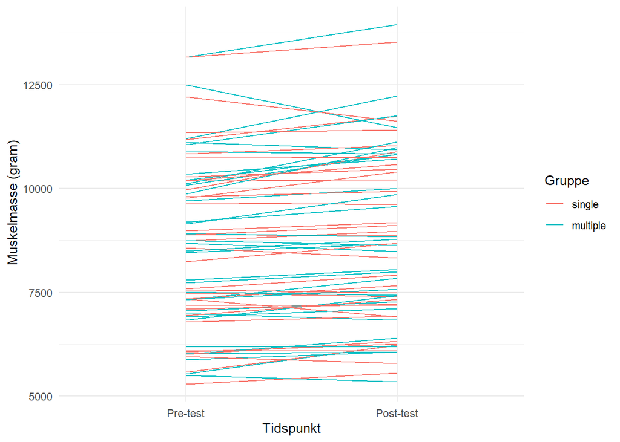

Figur 1 viser økningen i muskelvekst fra pre-test til post-tesst for alle forsøkspersoner skildt ved single- sett og multiple- sett

```r
figurmuskel
```

```r
tabellmuskel
```

[output not shown]

## Kilder

Galvão, Daniel A., and Dennis R. Taaffe. 2005. “Resistance Exercise Dosage in Older Adults: Single- Versus Multiset Effects on Physical Performance and Body Composition.” *Journal of the American Geriatrics Society* 53 (12): 2090–97. https://doi.org/10.1111/j.1532-5415.2005.00494.x.

Hass, Chris J., Linda Garzarella, Diego De Hoyos, and Michael L. Pollock. 2000. “Single Versus Multiple Sets in Long-Term Recreational Weightlifters.” *Medicine & Science in Sports & Exercise* 32 (1): 235. https://journals.lww.com/acsm-msse/Fulltext/2000/01000/Single_versus_multiple_sets_in_long_term.35.aspx.

Krieger, James W. 2009. “Single Versus Multiple Sets of Resistance Exercise: A Meta-Regression.” *The Journal of Strength & Conditioning Research* 23 (6): 18901901. https://doi.org/10.1519/JSC.0b013e3181b370be.

Radaelli, Regis, Eurico N. Wilhelm, Cíntia E. Botton, Anderson Rech, Martim Bottaro, Lee E. Brown, and Ronei S. Pinto. 2014. “Effects of Single Vs. Multiple-Set Short-Term Strength Training in Elderly Women.” *AGE* 36 (6): 9720. https://doi.org/10.1007/s11357-014-9720-6.

Schoenfeld, Brad J., Bret Contreras, James Krieger, Jozo Grgic, Kenneth Delcastillo, Ramon Belliard, and Andrew Alto. 2019. “Resistance Training Volume Enhances Muscle Hypertrophy but Not Strength in Trained Men.” *Medicine & Science in Sports & Exercise* 51 (1): 94103. https://doi.org/10.1249/MSS.0000000000001764.

Schoenfeld, Brad J., Dan Ogborn, and James W. Krieger. 2016. “Effects of Resistance Training Frequency on Measures of Muscle Hypertrophy: A Systematic Review and Meta-Analysis.” *Sports Medicine* 46 (11): 1689–97. https://doi.org/10.1007/s40279-016-0543-8.

Statistisk sentralbyrå. 2019. “Styrketrening stadig mer populært.” https://www.ssb.no/kultur-og-fritid/artikler-og-publikasjoner/styrketrening-stadig-mer-populaert.